# Project: Investigate The Movie Database (TMDb)

- Introduction
- Data Wrangling
- Exploratory Data Analysis
- Conclusions
- Limitations

## Introduction

> This dataset contains information of several thousand movies including budget, revenue, cast, and genre. The research will explore the following interesting questions:

> 1) Which genres are most popular from year to year?

> 2) What kinds of properties are associated with movies that have the highest-grossing movies?

```python
#Import python libraries
import numpy as np
import pandas as pd
import matplotlib.pyplot as plt
%matplotlib inline
```

```python
#Custom settings to make pandas output look better
pd.set_option('display.max_rows', 10000)
pd.set_option('display.max_columns', 21)
```

## Data Wrangling

```python
#Read the csv file using pandas
df=pd.read_csv('tmdb-movies.csv')
```

```python
#Retrieve information about the range index, data columns(including dtypes), and non-null values
df.info()
```

```
<class 'pandas.core.frame.DataFrame'>
RangeIndex: 10866 entries, 0 to 10865
Data columns (total 21 columns):
id                      10866 non-null int64
imdb_id                 10856 non-null object
popularity              10866 non-null float64
budget                  10866 non-null int64
revenue                 10866 non-null int64
original_title          10866 non-null object
cast                    10790 non-null object
homepage                2936 non-null object
director                10822 non-null object
tagline                 8042 non-null object
keywords                9373 non-null object
overview                10862 non-null object
runtime                 10866 non-null int64
genres                  10843 non-null object
production_companies    9836 non-null object
release_date            10866 non-null object
vote_count              10866 non-null int64
vote_average            10866 non-null float64
release_year            10866 non-null int64
budget_adj              10866 non-null float64
revenue_adj             10866 non-null float64
dtypes: float64(4), int64(6), object(11)
memory usage: 1.7+ MB
```

```python
#Find any missing data
df.describe()
```

|  | id | popularity | budget | revenue | runtime | vote_count | vote_average | release_year | budget_adj | revenue_adj |
| --- | --- | --- | --- | --- | --- | --- | --- | --- | --- | --- |
| count | 10866.000000 | 10866.000000 | 1.086600e+04 | 1.086600e+04 | 10866.000000 | 10866.000000 | 10866.000000 | 10866.000000 | 1.086600e+04 | 1.086600e+04 |
| mean | 66064.177434 | 0.646441 | 1.462570e+07 | 3.982332e+07 | 102.070863 | 217.389748 | 5.974922 | 2001.322658 | 1.755104e+07 | 5.136436e+07 |
| std | 92130.136561 | 1.000185 | 3.091321e+07 | 1.170035e+08 | 31.381405 | 575.619058 | 0.935142 | 12.812941 | 3.430616e+07 | 1.446325e+08 |
| min | 5.000000 | 0.000065 | 0.000000e+00 | 0.000000e+00 | 0.000000 | 10.000000 | 1.500000 | 1960.000000 | 0.000000e+00 | 0.000000e+00 |
| 25% | 10596.250000 | 0.207583 | 0.000000e+00 | 0.000000e+00 | 90.000000 | 17.000000 | 5.400000 | 1995.000000 | 0.000000e+00 | 0.000000e+00 |
| 50% | 20669.000000 | 0.383856 | 0.000000e+00 | 0.000000e+00 | 99.000000 | 38.000000 | 6.000000 | 2006.000000 | 0.000000e+00 | 0.000000e+00 |
| 75% | 75610.000000 | 0.713817 | 1.500000e+07 | 2.400000e+07 | 111.000000 | 145.750000 | 6.600000 | 2011.000000 | 2.085325e+07 | 3.369710e+07 |
| max | 417859.000000 | 32.985763 | 4.250000e+08 | 2.781506e+09 | 900.000000 | 9767.000000 | 9.200000 | 2015.000000 | 4.250000e+08 | 2.827124e+09 |

```python
#Count the number of nonzeros in the adjusted budget and revenue columns
b= np.count_nonzero(df['budget_adj'])
r= np.count_nonzero(df['revenue_adj'])
print(b,r)
```

```
5170 4850
```

### General Properties

> As seen above, there are 21 columns with 10,866 rows (movie entries). For this research project, there are only 5 columns of interest: genres, vote average, release year, adjusted budget, and adjusted revenue so the rest of the columns need to be removed. In addition, the nan values in the genre column need to be replaced with empty strings inorder to match the non-values in the other columns. Given that a movie production isn't possible without a revenue or budget and more than half of the values in these columns are 0, the values need to be replaced with the mean of the column.

### Data Cleaning and Trimming

```python
#Drop the columns not analyzed in this project
df.drop(['id','imdb_id','popularity','budget', 'revenue','original_title','cast',
         'homepage', 'director', 'tagline','keywords','overview','runtime', 'production_companies', 'release_date',
         'vote_count'], axis= 1, inplace=True)
```

```python
#Replace nan values with empty strings
df.genres.fillna('', inplace=True)
```

```python
#Replace all 0's in two columns in with the column's mean value
df['budget_adj'].replace(to_replace=0, value = df['budget_adj'].mean(), inplace = True)
df['revenue_adj'].replace(to_replace=0, value = df['revenue_adj'].mean(), inplace = True)
```

```python
#Retrieve information about the range index, data columns(including dtypes), and non-null values
df.info()
```

```
<class 'pandas.core.frame.DataFrame'>
RangeIndex: 10866 entries, 0 to 10865
Data columns (total 5 columns):
genres          10866 non-null object
vote_average    10866 non-null float64
release_year    10866 non-null int64
budget_adj      10866 non-null float64
revenue_adj     10866 non-null float64
dtypes: float64(3), int64(1), object(1)
memory usage: 424.5+ KB
```

> Now that the data has been trimmed and cleaned, the data is ready for exploration in the following section. Visualizations will help address the research questions posed in the introduction section.

## Exploratory Data Analysis

### Which genres are most popular from year to year?

```python
#Create a new data frame consisting of only the genres and release year columns from the existing data frame
df2 = df.loc[:,['genres', 'release_year', 'vote_average']]
df2.head()
```

|  | genres | release_year | vote_average |
| --- | --- | --- | --- |
| 0 | Action\|Adventure\|Science Fiction\|Thriller | 2015 | 6.5 |
| 1 | Action\|Adventure\|Science Fiction\|Thriller | 2015 | 7.1 |
| 2 | Adventure\|Science Fiction\|Thriller | 2015 | 6.3 |
| 3 | Action\|Adventure\|Science Fiction\|Fantasy | 2015 | 7.5 |
| 4 | Action\|Crime\|Thriller | 2015 | 7.3 |

> Consider that popular genres have a voting average of 7 or higher.

```python
#Create a new data frame with a voting average of 7 or higher
df2=df2[df2['vote_average'] >=7]
df2.head()
```

|  | genres | release_year | vote_average |
| --- | --- | --- | --- |
| 1 | Action\|Adventure\|Science Fiction\|Thriller | 2015 | 7.1 |
| 3 | Action\|Adventure\|Science Fiction\|Fantasy | 2015 | 7.5 |
| 4 | Action\|Crime\|Thriller | 2015 | 7.3 |
| 5 | Western\|Drama\|Adventure\|Thriller | 2015 | 7.2 |
| 7 | Drama\|Adventure\|Science Fiction | 2015 | 7.6 |

```python
#Split the genre values on '|' and separate them into columns. Then, melt the result.
#For more information: https://stackoverflow.com/questions/46143309/counting-multiple-values-in-a-groupby-object
df3 = pd.melt(
    pd.concat([df2['release_year'],
               df2.loc[:, 'genres'].apply(
                   lambda series: series.split('|')).apply(pd.Series)], axis=1),
    id_vars='release_year')[['release_year', 'value']]
df3.head()
```

|  | release_year | value |
| --- | --- | --- |
| 0 | 2015 | Action |
| 1 | 2015 | Action |
| 2 | 2015 | Action |
| 3 | 2015 | Western |
| 4 | 2015 | Drama |

```python
#Group by release year and count the genres
result = df3.groupby('release_year')['value'].value_counts()
#Convert Panda Series to a data frame
result= result.to_frame()
#Rename the value column to counts column
result= result.rename(columns={'value':'counts'}).reset_index()
result.head(1)
```

|  | release_year | value | counts |
| --- | --- | --- | --- |
| 0 | 1960 | Comedy | 3 |

```python
#Create a new counts_pcts column as a percentage of the total genres for each year
result['counts_pcts'] = result.groupby(['release_year'])['counts'].apply(lambda x:100 * x /(x.sum()))
result.head(1)
```

|  | release_year | value | counts | counts_pcts |
| --- | --- | --- | --- | --- |
| 0 | 1960 | Comedy | 3 | 12.5 |

```python
#Index genres and sort by genre and release year
result_value_indexed = result.set_index('value').sort_values(by=['value', 'release_year'])
result_value_indexed.tail(1)
```

| value | release_year | counts | counts_pcts |
| --- | --- | --- | --- |
| Western | 2015 | 2 | 0.83682 |

```python
#Create a list of unique genres
new_list= result['value'].unique()
new_list= sorted(new_list)
new_list
```

```
['',
 'Action',
 'Adventure',
 'Animation',
 'Comedy',
 'Crime',
 'Documentary',
 'Drama',
 'Family',
 'Fantasy',
 'Foreign',
 'History',
 'Horror',
 'Music',
 'Mystery',
 'Romance',
 'Science Fiction',
 'TV Movie',
 'Thriller',
 'War',
 'Western']
```

### Film Genre Popularity of the Top 7 Genres in 1960

```python
#Create a data frame of the top 7 genres in 1960 and 2015
Top7_1960 = result[result.release_year == 1960].sort_values(by="counts_pcts", ascending=False).head(7)
Top7_2015 = result[result.release_year == 2015].sort_values(by="counts_pcts", ascending=False).head(7)
```

```python
#Create a list of the top 7 genres in 1960 and 2015
Top7_1960_list= Top7_1960['value'].unique()
Top7_2015_list= Top7_2015['value'].unique()
```

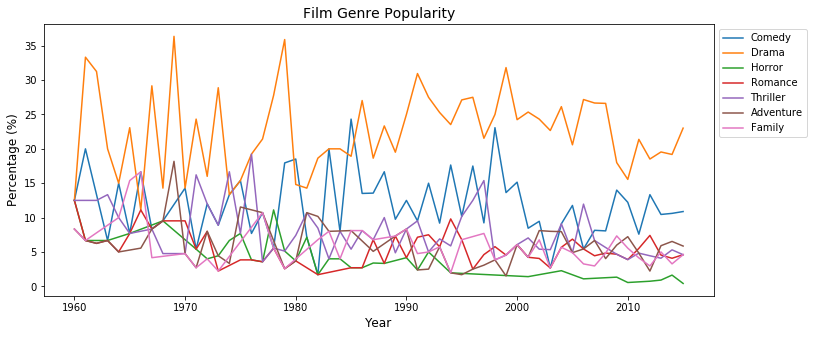

```python
#Plot line graphs of the top 7 genres in 1960
def plot(x):
    plt.figure(figsize = (12, 5))
    for i in x:
        p = result_value_indexed.loc[i]
        plt.plot(p["release_year"], p["counts_pcts"])
        plt.legend(x, bbox_to_anchor=(1, 1))
        plt.title('Film Genre Popularity', fontsize=14)
        plt.xlabel('Year', fontsize=12)
        plt.ylabel('Percentage (%)', fontsize=12)

plot(Top7_1960_list)
```

### Film Genre Popularity of the Top 7 Genres in 2015

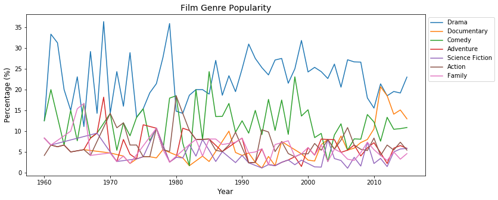

```python
#Plot line graphs of the top 7 genres in 2015
plot(Top7_2015_list)
```

> Given that the overall number of films have been increasing over the years, it is preferable to graph the film genre popularity as a percentage of the total genres for each year rather than number of genres.

> Graphing all the genres in one plot makes the visualization much more convoluted and thereby much harder to draw conclusions. It is easier to look at the top 7 genres of the earliest and final year.

> The next section explores the attributes associated with the highest-grossing films.

### What kinds of properties are associated with movies that have the highest-grossing movies?

> Consider that the highest-grossing movies have at least 1 billion dollars in revenue. Adjusted budget and adjusted revenue are used in place of budget and revenue to account for inflation over time.

> The production costs, average rating, and genres are analyzed to determine any possible associations/correlations with the top-grossing films.

```python
#Create the highest-grossing movies data frame with at least 1 billion dollars in revenue
#In addition, create another data frame with less than 1 billion dollars in revenue to be used in comparison
highest_grossing_movies =df[df['revenue_adj']>= 1000000000].sort_values(by='revenue_adj', ascending=False)
not_highest_grossing_movies= df[df['revenue_adj']<1000000000].sort_values(by='revenue_adj', ascending=False)
```

```python
# Find the mean of the vote average, budget, and revenue
mean1= highest_grossing_movies.mean()
mean2=not_highest_grossing_movies.mean()
print(mean1,mean2)
```

```
vote_average    7.177273e+00
release_year    1.997591e+03
budget_adj      1.334891e+08
revenue_adj     1.363139e+09
dtype: float64 vote_average    5.970033e+00
release_year    2.001338e+03
budget_adj      2.631739e+07
revenue_adj     7.458465e+07
dtype: float64
```

### Production Cost of the Hightest-Grossing Movies

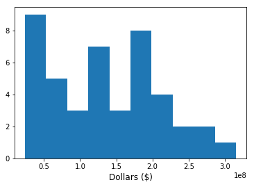

```python
#Plot a histogram of the highest-grossing films' budget
def histogram (x,y):
    plt.hist(x, bins=10)
    plt.xlabel(y, fontsize=12)
    plt.grid(False)
    plt.show()

histogram(highest_grossing_movies['budget_adj'], 'Dollars ($)')
```

### Production Cost of the Non-Hightest Grossing Movies

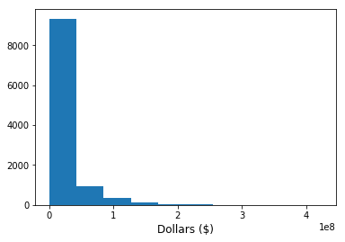

```python
#Plot a histogram of the non-highest-grossing films' budget
histogram(not_highest_grossing_movies['budget_adj'], 'Dollars ($)')
```

> While the budget of the highest-grossing movies are more distributed across the spectrum, the budget of the remaining movies are skewed to the right, costing approximately $20,000,000.

### Average Rating of the Hightest-Grossing Movies

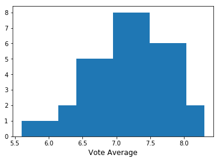

```python
#Plot a histogram of the highest-grossing films' vote averages
histogram(highest_grossing_movies['vote_average'], 'Vote Average')
```

### Average Rating of the Non-Hightest-Grossing Movies

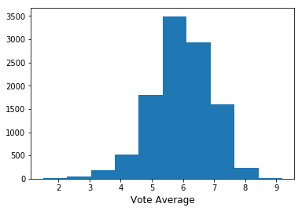

```python
#Plot a histogram of the non-highest-grossing films' vote averages
histogram(not_highest_grossing_movies['vote_average'], 'Vote Average')
```

> Most of the highest-grossing films rank above 7 while most of the other films rank below 7.

### Hightest-Grossing Genres

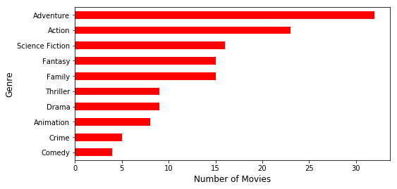

```python
#Plot a horizontal bar chart of the highest-grossing genres
def barh(x,y):
    x= x.str.get_dummies(sep='|').sum().sort_values(ascending=True)
    x=x.tail(10)
    x.plot(kind='barh', figsize=(8,4), color=y)
    plt.xlabel('Number of Movies', fontsize=12)
    plt.ylabel('Genre', fontsize=12)
    plt.show()

barh(highest_grossing_movies['genres'], 'r')
```

### Non-Hightest-Grossing Genres

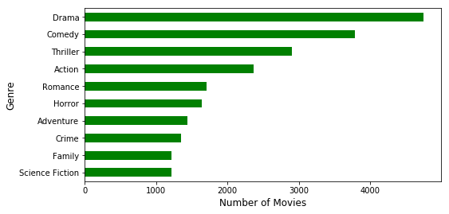

```python
#Plot a horizontal bar chart of the non-highest grossing genres
barh(not_highest_grossing_movies['genres'], 'g')
```

> Adventure and action are the most popular genres among the top-grossing films while drama and comedy are the most popular among the other films.

## Conclusions

> Drama is the most popular genre followed by comedy with documentary gaining much more popularity in recent years.

> There may be a correlation between a movies budget and revenue given that the highest-grossing films tend to have the highest production costs while the other films have a much smaller budget.

> Rating and movie revenue may also be correlated given that the top-grossing films tend to have a much higher vote average in contrast with other films.

> While adventure and action the most popular genres among the top-grossing films, drama and comedy are the most popular among the other films.

> Inferential statistics or machine learning were not used to complete this project, and thereby the findings are tentative.

## Limitations

> Missing data in the input data is a limitation given that about 10% of the data have null values. Moreover, more than half of the values in the budget/revenue and adjusted columns are 0. This may skew the analysis leading to biased or inaccurate analysis. The sample must be good enough to represent the population so that the analysis will have enough data to generalize the entire population.